# Exercise week 2

Shawn Schneidereit

2021-04-29

3.5. Practice Problems are labeled Easy (E), Medium (M), and Hard (H). Easy. The Easy problems use the samples from the posterior distribution for the globe tossing ex- ample. This code will give you a specific set of samples, so that you can check your answers exactly.

# Hard.

The Hard problems here all use the data below. These data indicate the gender (male=1, fe- male=0) of officially reported first and second born children in 100 two-child families.

```r
birth1 <- c(1,0,0,0,1,1,0,1,0,1,0,0,1,1,0,1,1,0,0,0,1,0,0,0,1,0,
0,0,0,1,1,1,0,1,0,1,1,1,0,1,0,1,1,0,1,0,0,1,1,0,1,0,0,0,0,0,0,0,
1,1,0,1,0,0,1,0,0,0,1,0,0,1,1,1,1,0,1,0,1,1,1,1,1,0,0,1,0,1,1,0,
1,0,1,1,1,0,1,1,1,1)
birth2 <- c(0,1,0,1,0,1,1,1,0,0,1,1,1,1,1,0,0,1,1,1,0,0,1,1,1,0,
1,1,1,0,1,1,1,0,1,0,0,1,1,1,1,0,0,1,0,1,1,1,1,1,1,1,1,1,1,1,1,1,
1,1,1,0,1,1,0,1,1,0,1,1,1,0,0,0,0,0,0,1,0,0,0,1,1,0,0,1,0,0,1,1,
0,0,0,1,1,1,0,0,0,0)
```

So for example, the first family in the data reported a boy (1) and then a girl (0). The second family reported a girl (0) and then a boy (1). The third family reported two girls. You can load these two vectors into R’s memory by typing:

```r
library(rethinking)
data(homeworkch3)
```

Use these vectors as data. So for example to compute the total number of boys born across all of these births, you could use:

```r
boys_sum <- sum(birth1) + sum(birth2)
```

### 3H1.

Using grid approximation, compute the posterior distribution for the probability of a birth being a boy. Assume a uniform prior probability. Which parameter value maximizes the posterior probability?

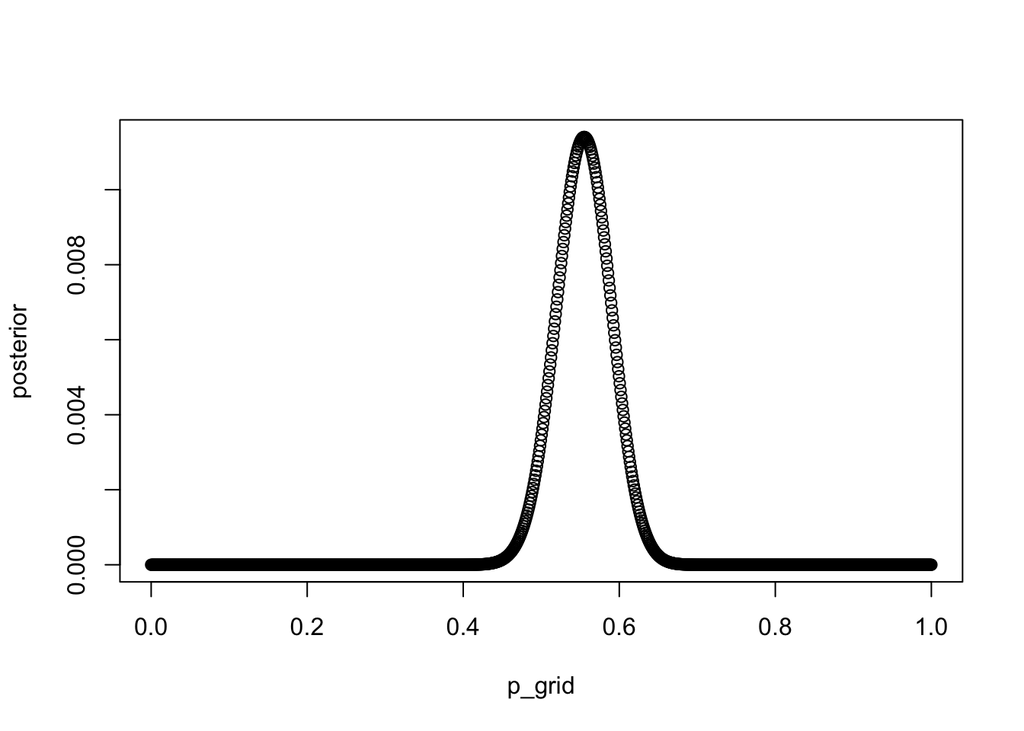

```r
p_grid <- seq( from=0 , to=1 , length.out=1000 )
prior <- rep(1,200)
likelihood <- dbinom( boys_sum , size=200 , prob=p_grid )
posterior <- likelihood * prior
posterior <- posterior / sum(posterior)
plot(p_grid, posterior, type="b")
```

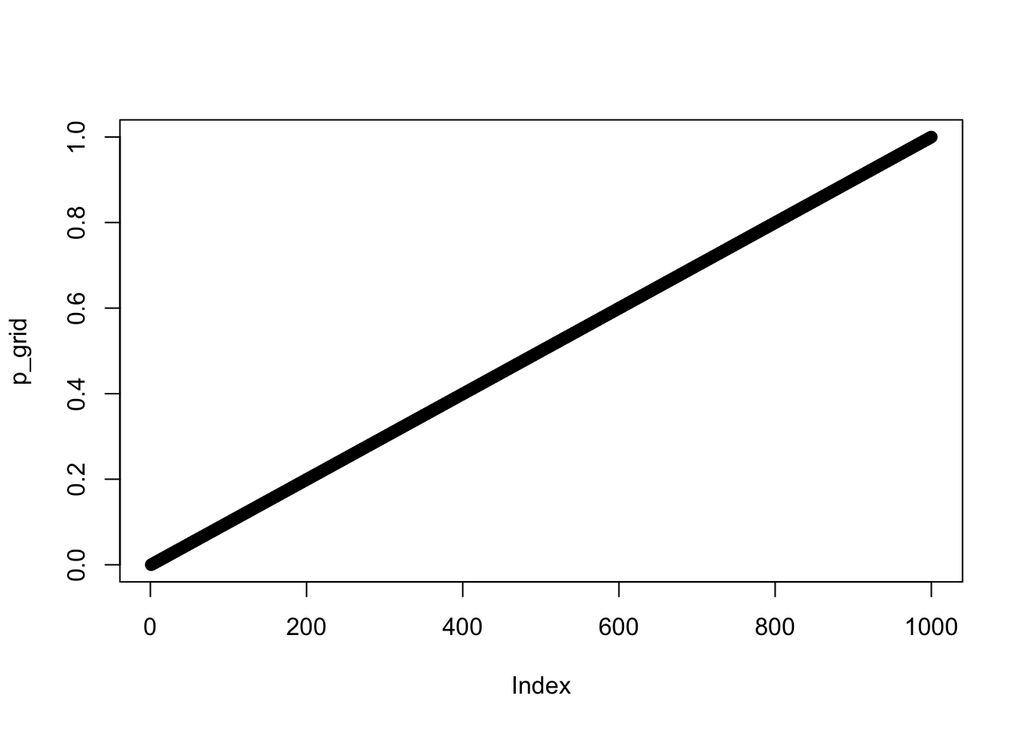

```r
plot(p_grid)
```

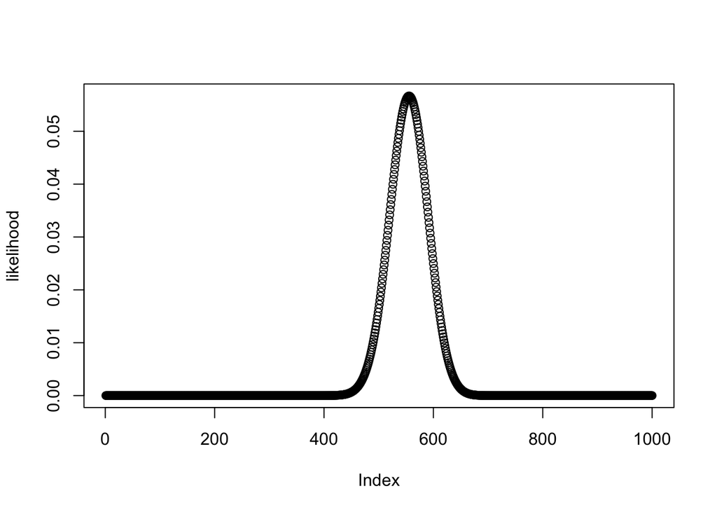

```r
plot(likelihood)
```

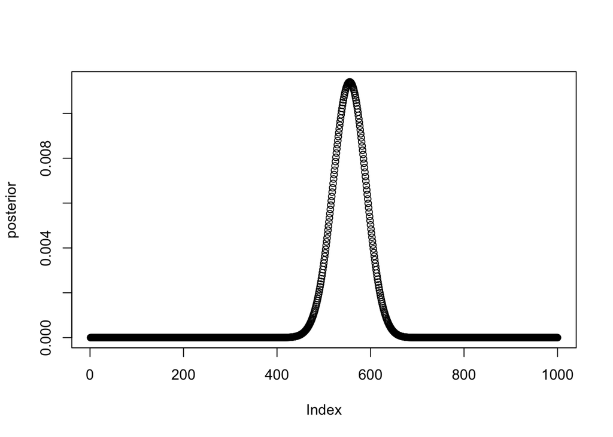

```r
plot(posterior)
```

```r
p_grid[which.max(posterior)] # 0.55 maximizes the posterior prob.
```

```
## [1] 0.5545546
```

### 3H2.

Using the sample function, draw 10,000 random parameter values from the posterior distribution you calculated above. Use these samples to estimate the 50%, 89%, and 97% highest posterior density intervals.

```r
samples <- sample(p_grid, prob=posterior, size=10000, replace=TRUE)
HPDI(samples, prob=0.5)
```

```
##      |0.5      0.5|
## 0.5255255 0.5715716
```

```r
HPDI(samples, prob=0.89)
```

```
##     |0.89     0.89|
## 0.4964965 0.6076076
```

```r
HPDI(samples, prob=0.97)
```

```
##     |0.97     0.97|
## 0.4824825 0.6346346
```

### 3H3.

Use rbinom to simulate 10,000 replicates of 200 births. You should end up with 10,000 numbers, each one a count of boys out of 200 births. Compare the distribution of predicted numbers of boys to the actual count in the data (111 boys out of 200 births). There are many good ways to visualize the simulations, but the dens command (part of the rethinking package) is probably the easiest way in this case. Does it look like the model fits the data well? That is, does the distribution of predictions include the actual observation as a central, likely outcome?

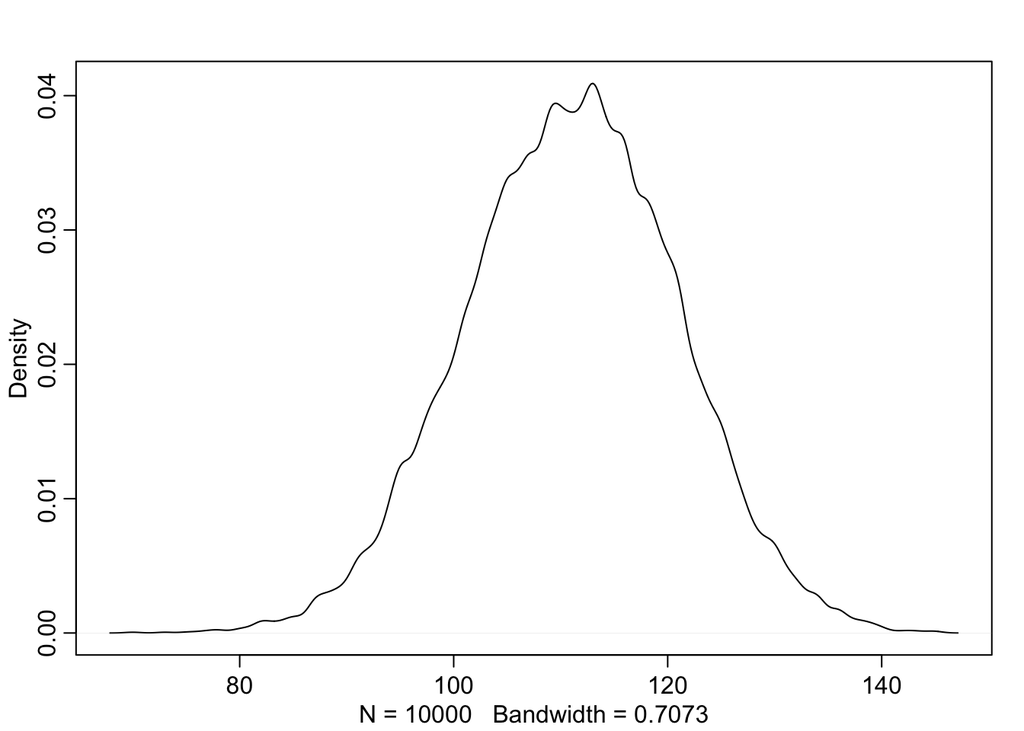

```r
sim <- rbinom( 10000 , size=200 , prob=samples)
dens(sim)
```

Yeah it looks like a pretty good fit. The distribution peaks around the known number of boys born (111), meaning that this would be the central likely outcome

# BRMS H 1-3

Using brms, compute the posterior distribution for the probability of a birth being a boy. Assume a uniform prior probability. Which parameter value maximizes the posterior probability?

```r
library(brms)
m1 <- brm(data = list(boys_sum = boys_sum),
          family = binomial(link = "identity"),
          boys_sum | trials(200) ~ 0 + Intercept,
          prior(beta(1, 1), class = b, lb = 0, ub = 1),
          iter = 10000,
          seed = 42)
```

```
## Trying to compile a simple C file
```

[output not shown]

```r
summary(m1)
```

```
##  Family: binomial
##   Links: mu = identity
## Formula: boys_sum | trials(200) ~ 0 + Intercept
##    Data: list(boys_sum = boys_sum) (Number of observations: 1)
## Samples: 4 chains, each with iter = 10000; warmup = 5000; thin = 1;
##          total post-warmup samples = 20000
##
## Population-Level Effects:
##           Estimate Est.Error l-95% CI u-95% CI Rhat Bulk_ESS Tail_ESS
## Intercept     0.55      0.03     0.49     0.62 1.00     7456     9404
##
## Samples were drawn using sampling(NUTS). For each parameter, Bulk_ESS
## and Tail_ESS are effective sample size measures, and Rhat is the potential
## scale reduction factor on split chains (at convergence, Rhat = 1).
```

```r
posterior_summary(m1)
```

```
##               Estimate  Est.Error       Q2.5     Q97.5
## b_Intercept  0.5546848 0.03482337  0.4869301  0.621925
## lp__        -4.7680149 0.69187503 -6.6977044 -4.268934
```

```r
fitted(m1)
```

```
##      Estimate Est.Error     Q2.5   Q97.5
## [1,]  110.937  6.964674 97.38602 124.385
```

```r
predict(m1)
```

```
##      Estimate Est.Error Q2.5 Q97.5
## [1,] 110.9668  9.903946   92   130
```

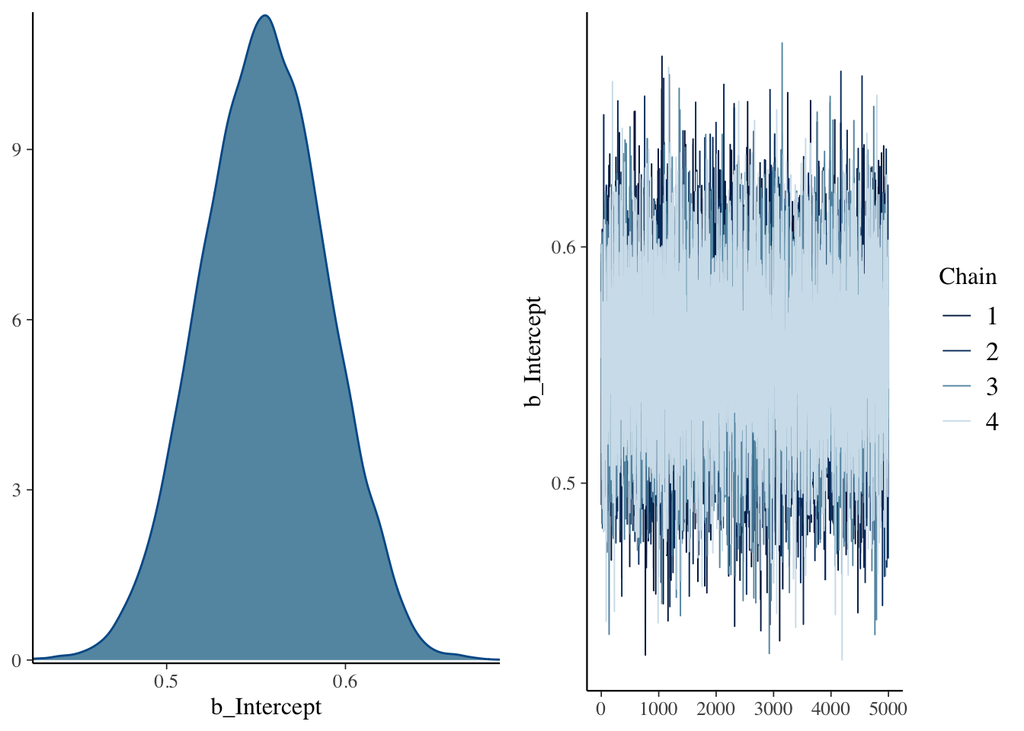

```r
plot(m1)
```

From the summary of the brms model, we can see that as before (in the grid approximation), the parameter value 0.55 (est error 0.03) maximizes the posterior probability

### 3H2.

Using the sample function, draw 10,000 random parameter values from the posterior distribution you calculated above. Use these samples to estimate the 50%, 89%, and 97% highest posterior density intervals.

```r
f <-fitted(m1,
         summary = F,
         scale   = "linear") %>%
  as.vector()

HPDI(f, prob=0.5)
```

```
##      |0.5      0.5|
## 0.5315525 0.5791127
```

```r
HPDI(f, prob=0.89)
```

```
##     |0.89     0.89|
## 0.4978320 0.6091166
```

```r
HPDI(f, prob=0.97)
```

```
##     |0.97     0.97|
## 0.4787077 0.6263543
```

### 3H3.

Use rbinom to simulate 10,000 replicates of 200 births. You should end up with 10,000 numbers, each one a count of boys out of 200 births. Compare the distribution of predicted numbers of boys to the actual count in the data (111 boys out of 200 births). There are many good ways to visualize the simulations, but the dens command (part of the rethinking package) is probably the easiest way in this case. Does it look like the model fits the data well? That is, does the distribution of predictions include the actual observation as a central, likely outcome?

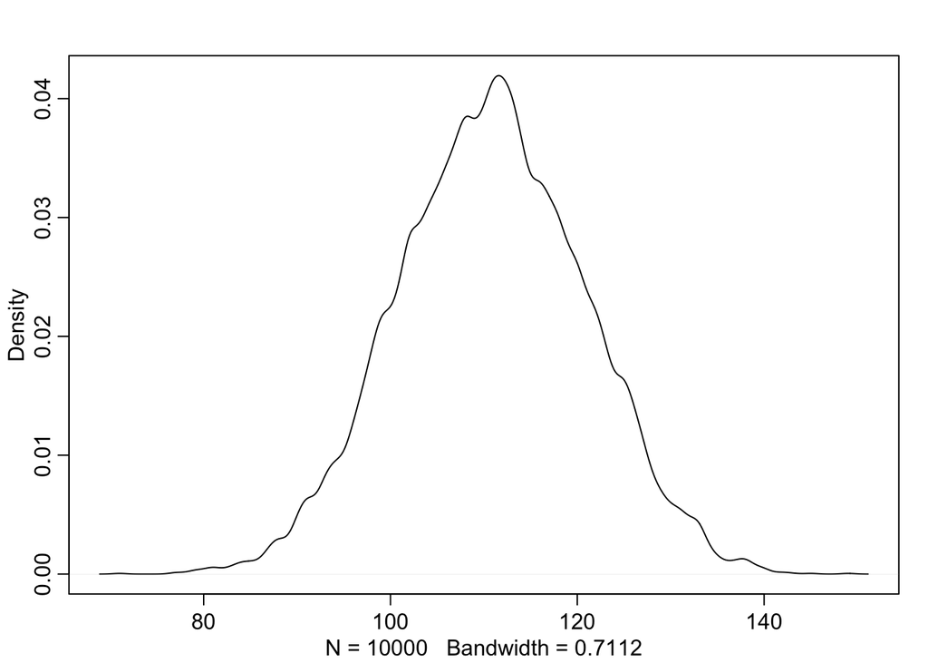

```r
sim <- rbinom( 10000 , size=200 , prob=f)
dens(sim)
```

looks quite similar as before, but overall I think it should be a good approximation, as it is quite centered on 111

# Easy

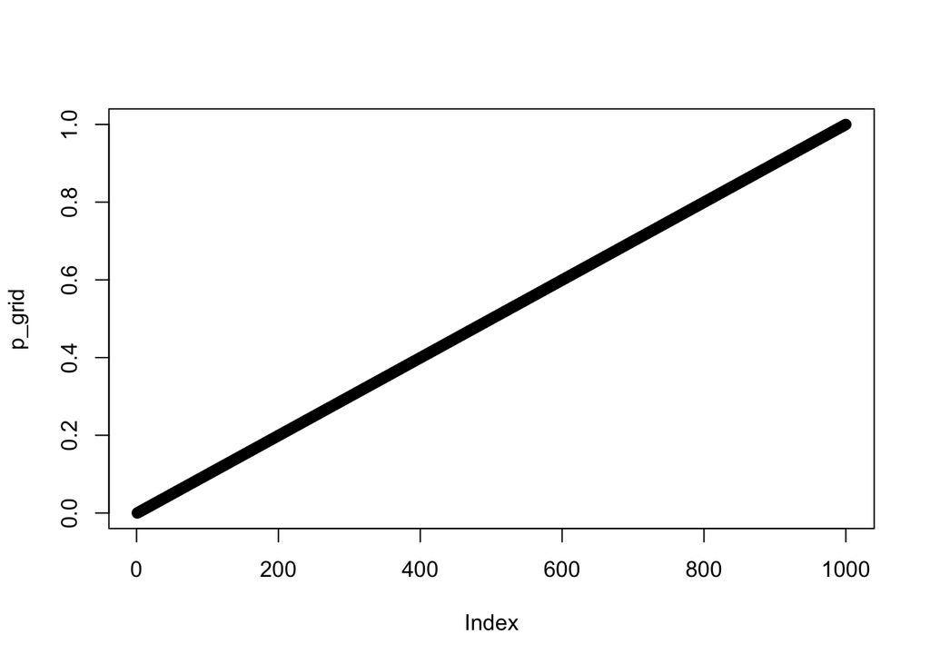

```r
p_grid <- seq( from=0 , to=1 , length.out=1000 )
prior <- rep( 1 , 1000 )
likelihood <- dbinom( 6 , size=9 , prob=p_grid )
posterior <- likelihood * prior
posterior <- posterior / sum(posterior)
set.seed(100)
samples <- sample( p_grid , prob=posterior , size=1e4 , replace=TRUE )


plot(p_grid)
```

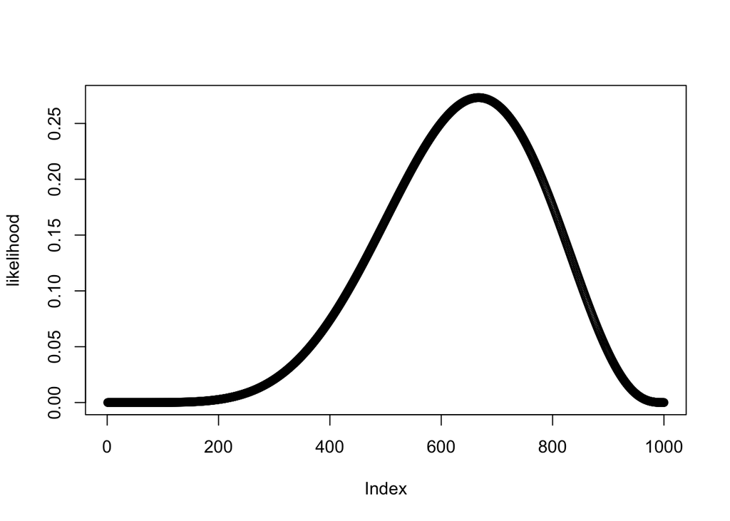

```r
plot(likelihood)
```

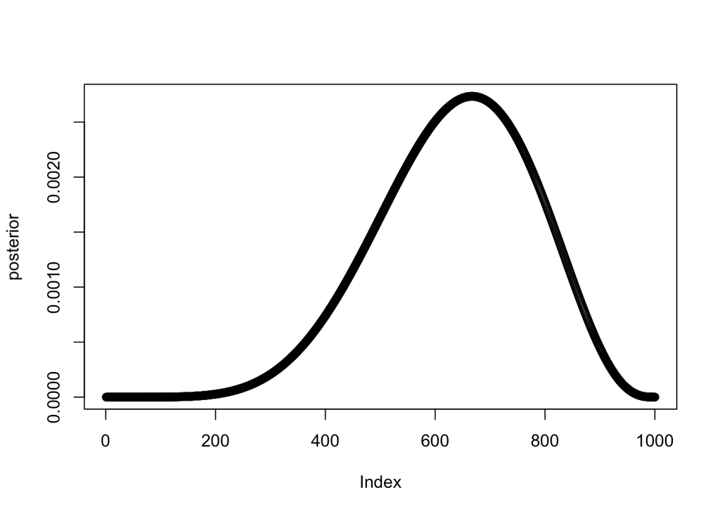

```r
plot(posterior) # we had a flat prior -> same shape; new scale
```

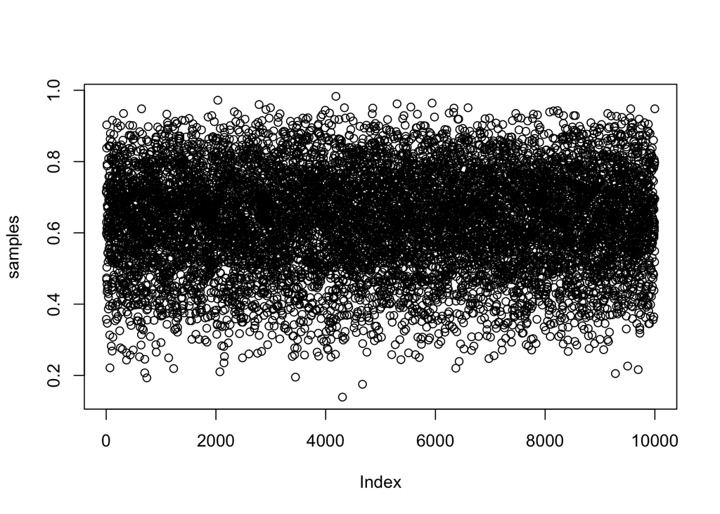

```r
plot(samples)
```

Use the values in samples to answer the questions that follow.

### 3E1.

How much posterior probability lies below p = 0.2?

```r
# add up posterior probability where p < 0.2
mean(samples < 0.2)
```

```
## [1] 4e-04
```

### 3E2.

How much posterior probability lies above p = 0.8?

```r
# add up posterior probability where p < 0.8
mean(samples > 0.8)
```

```
## [1] 0.1116
```

### 3E3.

How much posterior probability lies between p = 0.2 and p = 0.8?

```r
# add up posterior probability where p > 0.2 & p < 0.8
 mean(samples > 0.2 & samples < 0.8 )
```

```
## [1] 0.888
```

### 3E4.

20% of the posterior probability lies below which value of p?

```r
quantile( samples , 0.2 )
```

```
##       20%
## 0.5185185
```

### 3E5.

20% of the posterior probability lies above which value of p?

```r
quantile( samples , 0.8 )
```

```
##       80%
## 0.7557558
```

### 3E6.

Which values of p contain the narrowest interval equal to 66% of the posterior probability?

```r
HPDI( samples , prob=0.66 )
```

```
##     |0.66     0.66|
## 0.5085085 0.7737738
```

### 3E7.

Which values of p contain 66% of the posterior probability, assuming equal posterior probability both below and above the interval?

```r
PI( samples , prob=0.66 )
```

```
##       17%       83%
## 0.5025025 0.7697698
```

### 3M1.

Suppose the globe tossing data had turned out to be 8 water in 15 tosses. Construct the posterior distribution, using grid approximation. Use the same flat prior as before.

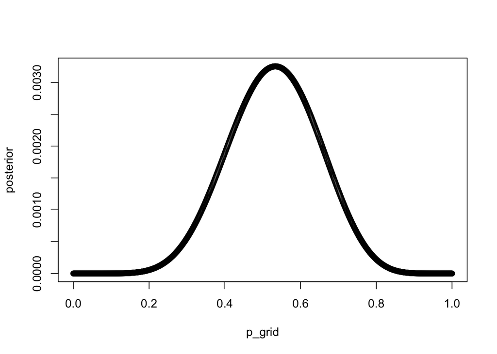

```r
p_grid <- seq( from=0 , to=1 , length.out=1000 )
prior <- rep( 1 , 1000 )
likelihood <- dbinom( 8 , size=15 , prob=p_grid )
posterior <- likelihood * prior
posterior <- posterior / sum(posterior)
plot(p_grid, posterior, type="b")
```

### 3M2.

Draw 10,000 samples from the grid approximation from above. Then use the samples to cal- culate the 90% HPDI for p.

```r
samples <- sample( p_grid , prob=posterior , size=1e4 , replace=TRUE )
HPDI( samples , prob=0.90 )
```

```
##      |0.9      0.9|
## 0.3293293 0.7167167
```